# Laboratiorium 2 ze statystyki

#### Cele

- Celem zadań 1,2 i 4 jest zastosowanie twierdzenia z wykładu mówiącego, że jeśli $\hat{\theta}$ jest ENW parametru $\theta$ a $g = g(\theta)$ funkcją parametru $\theta$, to $g(\hat{\theta})$ jest ENW wielkości $g$ i porównanie wyników z oczekiwaniami.
- W zadaniu 4 użyjemy wykresu kwantylowego do sprawdzenia czy rozkład danych jest normalny.
- Zadanie 5 to porównanie wyników eksperymentalnego wyznaczania ENW dla rozkładów: normalnego i Laplace’a.
- W zadaniu 6 sprawdzamy, jaki wpływ na szacowania ma rozmiar próby.

#### Zadanie 1 - rozkład dwumianowy

Wielkość $P(X \leq 3)$ jest funkcją parametru $p$:
$$P(p) = {5 \choose 3}p^3(1-p)^{1-3} + {5 \choose 4}p^4(1-p)^{1-4} + {5 \choose 5}p^5(1-p)^{1-5}$$
stąd estymator nawiększej wiarogodności $P$ otrzymamy wyznaczając ENW $p$ (dla tego rozkładu jest nim proporcja sukcesów) i przekazując otrzymaną wartość do funkcji $P(p)$.

Tabela 1: Średni błąd kwadratowy, wariancja i obciążenie estymatora największej wiarogodności P dla wybranych wartości parametru

| p | n | MSE | bias | var |
| --- | --- | --- | --- | --- |
| 0.1 | 50 | 0.0082477 | -0.0906803 | 0.0003642 |
| 0.3 | 50 | 0.0198273 | -0.1353981 | 0.0008587 |
| 0.5 | 50 | 0.0035856 | -0.0008535 | 0.0010366 |
| 0.9 | 50 | 0.0082477 | 0.0906803 | 0.0003642 |

1. Estymowane wartości $P(X \leq 3)$ są bliskie prawdziwym teoretycznym wartościom, a MSE, obciążenie i wariancja małe - oznacza to, że wybrany sposób estymacji jest bardzo dobry.
2. Wykonując dodatkowe eksperymenty można zauważyć, że wartości MSE, obciążenia i wariancji są symetryczne względem $p = 0.5$.

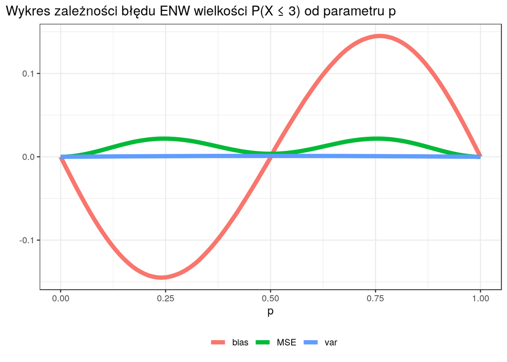

#### Zadanie 2 - rozkład Poissona

Estymatorem największej wiarogodności parametru $\lambda$ jest średnia arytmetyczna. W celu wyznaczenia ENW $P(X = x)$, korzystamy z tego samego sposobu co w zadaniu 1.

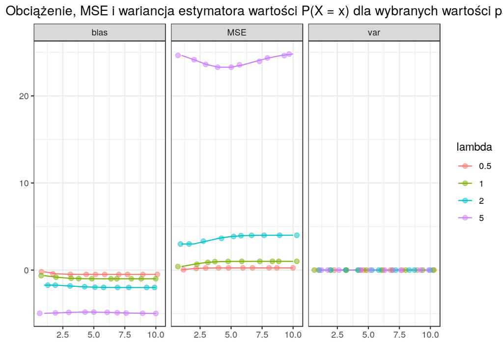

1. Wariancja jest niezależnie od $\lambda$ praktycznie zerowa.
2. Obciążenie i bezwzględna wartość średniego błędu kwadratowego rosną wraz ze wzrostem $\lambda$, ale nie różnią się znacząco dla różnych wartości $x$. Przeprowadziłam dodatkowe eksperymenty i sprawdziłam jak wygląda zależność obciążenia i MSE od $\lambda$.

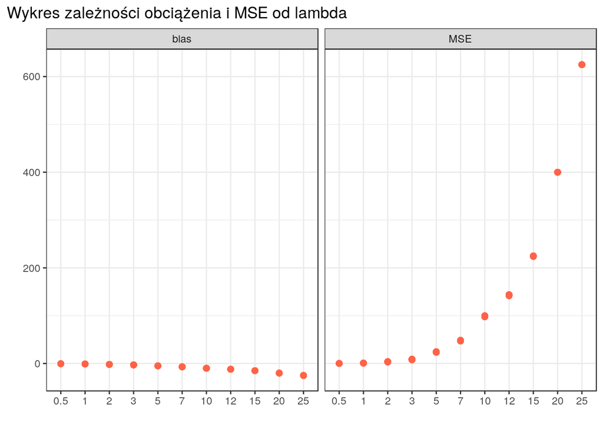

#### Zadanie 4

Gdy $\beta = 1$, to: funkcja masy prawdopodobieństwa jest postaci $P(x|\theta) = \theta x^{\theta - 1}$, informacja Fishera jest funkcją parametru $\theta$: $I(\theta) = \frac{1}{\theta^2}$, a estymator największej wiarogodności $\theta$ można wyrazić zwartym wzorem: $\hat{\theta} = \frac{-n}{\sum{ln(x_i)}}$. Analogicznie do poprzednich zadań $\hat{I(\theta)} = I(\hat{\theta})$.

```r
mle_beta1 <- function(X){
  n = length(X)
  return(-n/sum(log(X)))
}

fisher <- function(theta){return(1/theta^2)}
```

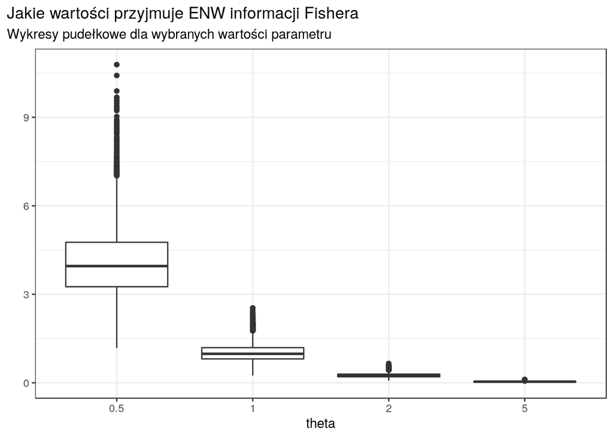

W dalszej części za zapamiętaną wartość estymatora $\hat{I(\theta)}$ przyjmiemy średnią arytmetyczną wyników - takie oszacowanie powinno mieć tym mniejsze znaczenie, im większa będzie wartość $\theta$ ze względu na mniejszy rozrzut estymatora. Uwagi :

1. prezentowane wyniki są obliczane dla innych prób losowych niż użyte wcześniej.
2. krzywa normalna naniesiona na histogramy rysowana jest z użyciem średniej i odchylenia standardowego liczonych dla wszystkich wartości $Y$ (tzn. $\theta = 0.5, 1, 2, 5$). Nie robi to dużej różnicy, gdyż indywidualne wyniki są pbardzo podobne.

Tabela 2: Porównanie średniej i wariancji Y dla różnych wartości parametru

| th | mean | sd |
| --- | --- | --- |
| 0.5 | 0.1366671 | 1.054771 |
| 1 | 0.1363110 | 1.060381 |
| 2 | 0.1597466 | 1.063109 |
| 5 | 0.1691760 | 1.080923 |

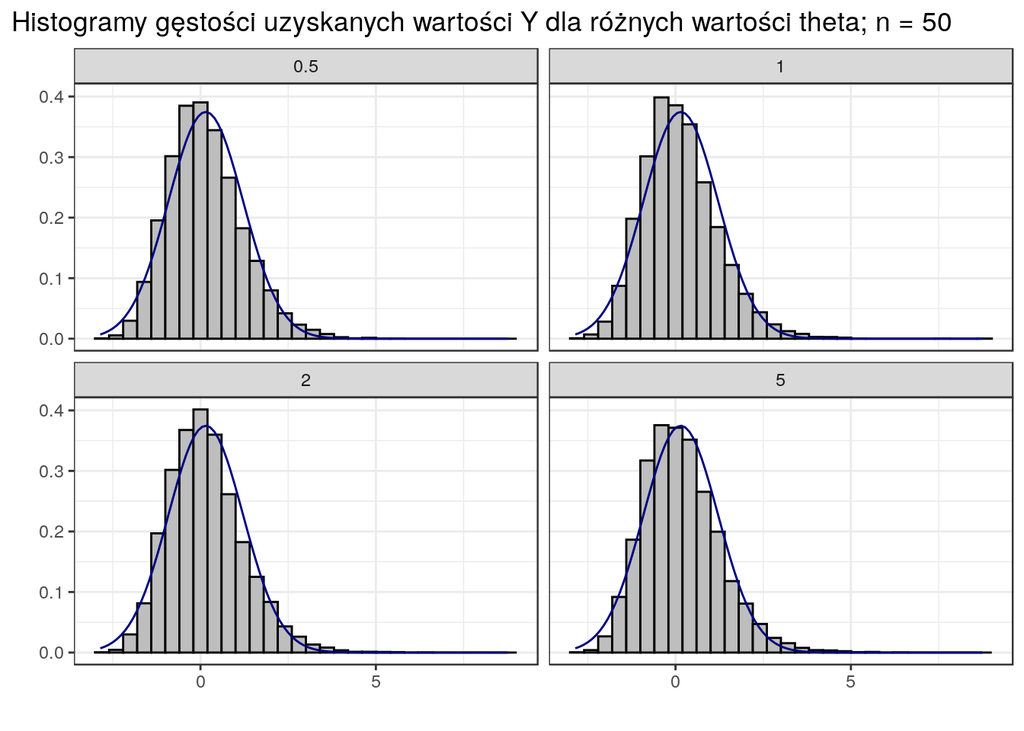

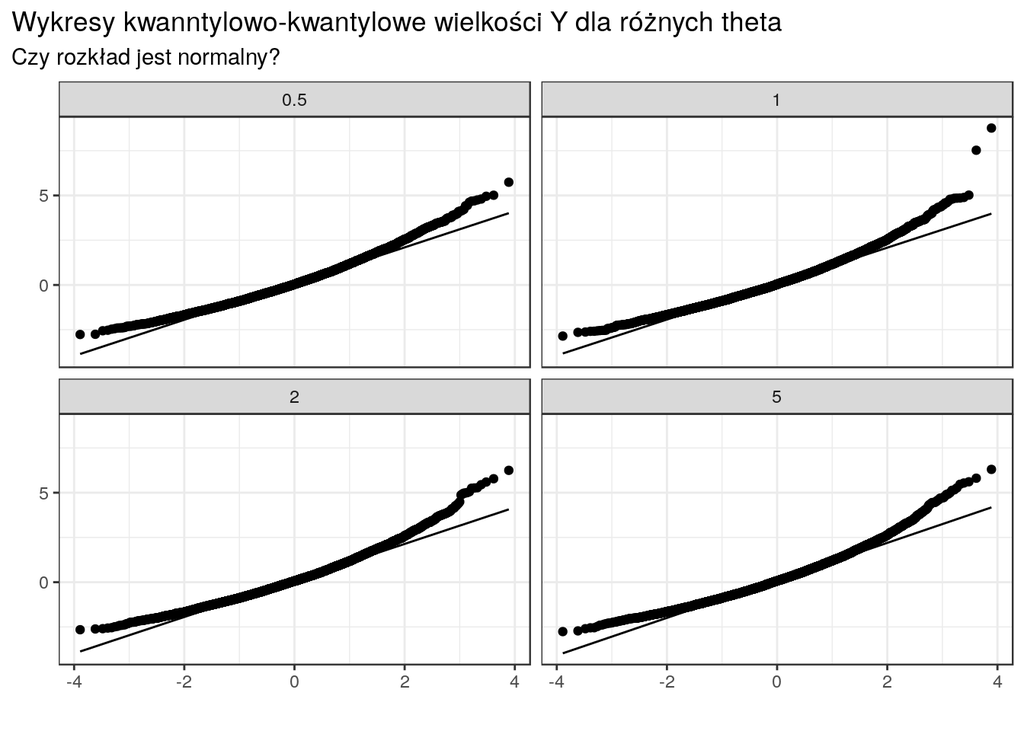

Wygląd wykresów pozwala stwierdzić, że rozkład wielkości $Y$ jest bardzo bliski rozkładowi normalnemu i lekko skośny względem niego.

#### Zadanie 5

Tabela 4: Wyniki zadania 5c

|  | MSE | bias | var |
| --- | --- | --- | --- |
| th1 | 0.0395111 | -0.0015393 | 0.0395126 |
| th2 | 0.0240074 | -0.0010795 | 0.0240087 |
| th3 | 2.7499850 | 0.0304426 | 2.7493332 |
| th4 | 0.0399686 | 0.1025496 | 0.0294551 |

#### Zadanie 6.1

Po wykonaniu eksperymentu dla $n = 20$ i $n = 100$ okazało się, że rozmiar próby nie ma wpływu na kształt wykresu przedstawionego w zadaniu 1. Dla jeszcze mniejszych prób można zaobserwować różnice, co można wyjaśnić tym, że $n = 20$ często przyjmuje się za minimalną do uzyskania zgodnych z teorią wyników liczebność próby.

#### Zadanie 6.4

```r
zad4_1.results <- rbind(zad4_1.results, zadanie4_1(1,100)[[1]])
Y100_1 <- zadanie4_2(th = 1, n = 100)
```

[output not shown]

[output not shown]

[figure not shown]

```r
ggplot(Y.dtf, aes(sample = y)) + geom_qq() + stat_qq_line() + facet_wrap(~th) +
  theme_bw() +
  theme(plot.title.position = 'plot') +
  labs(x = '', y = '', title = 'Wykres kwanntylowo-kwantylowe wielkości Y dla theta = 1, n = 100')
```

[output not shown]